# Model Building homework

GlebV

```r
library(tidyverse)
```

### Get and prepare data

Get and inspect the data.

```r
glimpse(avocado)
```

```
Rows: 18,249
Columns: 14
$ X1             <dbl> 0, 1, 2, 3, 4, 5, 6, 7, 8, 9, 10, 11, 12, 13, 14, 15, 16, 1…
$ Date           <date> 2015-12-27, 2015-12-20, 2015-12-13, 2015-12-06, 2015-11-29…
$ AveragePrice   <dbl> 1.33, 1.35, 0.93, 1.08, 1.28, 1.26, 0.99, 0.98, 1.02, 1.07,…
$ `Total Volume` <dbl> 64236.62, 54876.98, 118220.22, 78992.15, 51039.60, 55979.78…
$ `4046`         <dbl> 1036.74, 674.28, 794.70, 1132.00, 941.48, 1184.27, 1368.92,…
$ `4225`         <dbl> 54454.85, 44638.81, 109149.67, 71976.41, 43838.39, 48067.99…
$ `4770`         <dbl> 48.16, 58.33, 130.50, 72.58, 75.78, 43.61, 93.26, 80.00, 85…
$ `Total Bags`   <dbl> 8696.87, 9505.56, 8145.35, 5811.16, 6183.95, 6683.91, 8318.…
$ `Small Bags`   <dbl> 8603.62, 9408.07, 8042.21, 5677.40, 5986.26, 6556.47, 8196.…
$ `Large Bags`   <dbl> 93.25, 97.49, 103.14, 133.76, 197.69, 127.44, 122.05, 562.3…
$ `XLarge Bags`  <dbl> 0.00, 0.00, 0.00, 0.00, 0.00, 0.00, 0.00, 0.00, 0.00, 0.00,…
$ type           <chr> "conventional", "conventional", "conventional", "convention…
$ year           <dbl> 2015, 2015, 2015, 2015, 2015, 2015, 2015, 2015, 2015, 2015,…
$ region         <chr> "Albany", "Albany", "Albany", "Albany", "Albany", "Albany",…
```

```r
library(lubridate)
library(janitor)
```

Tidy up data:

I defined date_of_month and month as factors variables, as they might provide some insight. I also converted year as.factor, as year does not represent continuous data.

```r
clean_avocado <- avocado  %>%
  mutate(month = as.factor(month(Date)),
         day_of_month = as.factor(mday(Date)),
         year = as.factor(year)) %>%
  clean_names() %>%
  select(-c(x1, date))

glimpse(clean_avocado)
```

```
Rows: 18,249
Columns: 14
$ average_price <dbl> 1.33, 1.35, 0.93, 1.08, 1.28, 1.26, 0.99, 0.98, 1.02, 1.07, …
$ total_volume  <dbl> 64236.62, 54876.98, 118220.22, 78992.15, 51039.60, 55979.78,…
$ x4046         <dbl> 1036.74, 674.28, 794.70, 1132.00, 941.48, 1184.27, 1368.92, …
$ x4225         <dbl> 54454.85, 44638.81, 109149.67, 71976.41, 43838.39, 48067.99,…
$ x4770         <dbl> 48.16, 58.33, 130.50, 72.58, 75.78, 43.61, 93.26, 80.00, 85.…
$ total_bags    <dbl> 8696.87, 9505.56, 8145.35, 5811.16, 6183.95, 6683.91, 8318.8…
$ small_bags    <dbl> 8603.62, 9408.07, 8042.21, 5677.40, 5986.26, 6556.47, 8196.8…
$ large_bags    <dbl> 93.25, 97.49, 103.14, 133.76, 197.69, 127.44, 122.05, 562.37…
$ x_large_bags  <dbl> 0.00, 0.00, 0.00, 0.00, 0.00, 0.00, 0.00, 0.00, 0.00, 0.00, …
$ type          <chr> "conventional", "conventional", "conventional", "conventiona…
$ year          <fct> 2015, 2015, 2015, 2015, 2015, 2015, 2015, 2015, 2015, 2015, …
$ region        <chr> "Albany", "Albany", "Albany", "Albany", "Albany", "Albany", …
$ month         <fct> 12, 12, 12, 12, 11, 11, 11, 11, 11, 10, 10, 10, 10, 9, 9, 9,…
$ day_of_month  <fct> 27, 20, 13, 6, 29, 22, 15, 8, 1, 25, 18, 11, 4, 27, 20, 13, …
```

```r
#check for NA values
summary(clean_avocado)
```

```
 average_price    total_volume          x4046              x4225
 Min.   :0.440   Min.   :      85   Min.   :       0   Min.   :       0
 1st Qu.:1.100   1st Qu.:   10839   1st Qu.:     854   1st Qu.:    3009
 Median :1.370   Median :  107377   Median :    8645   Median :   29061
 Mean   :1.406   Mean   :  850644   Mean   :  293008   Mean   :  295155
 3rd Qu.:1.660   3rd Qu.:  432962   3rd Qu.:  111020   3rd Qu.:  150207
 Max.   :3.250   Max.   :62505647   Max.   :22743616   Max.   :20470573

     x4770           total_bags         small_bags         large_bags
 Min.   :      0   Min.   :       0   Min.   :       0   Min.   :      0
 1st Qu.:      0   1st Qu.:    5089   1st Qu.:    2849   1st Qu.:    127
 Median :    185   Median :   39744   Median :   26363   Median :   2648
 Mean   :  22840   Mean   :  239639   Mean   :  182195   Mean   :  54338
 3rd Qu.:   6243   3rd Qu.:  110783   3rd Qu.:   83338   3rd Qu.:  22029
 Max.   :2546439   Max.   :19373134   Max.   :13384587   Max.   :5719097

  x_large_bags          type             year         region              month
 Min.   :     0.0   Length:18249       2015:5615   Length:18249       1      :1944
 1st Qu.:     0.0   Class :character   2016:5616   Class :character   3      :1836
 Median :     0.0   Mode  :character   2017:5722   Mode  :character   2      :1728
 Mean   :  3106.4                      2018:1296                      5      :1512
 3rd Qu.:   132.5                                                     7      :1512
 Max.   :551693.7                                                     10     :1512
                                                                      (Other):8205
  day_of_month
 4      :  756
 11     :  756
 18     :  755
 25     :  755
 1      :  648
 3      :  648
 (Other):13931
```

Check for aliased variables in the dataset:

```r
alias(lm(average_price ~ . , data = clean_avocado))
```

```
Model :
average_price ~ total_volume + x4046 + x4225 + x4770 + total_bags +
    small_bags + large_bags + x_large_bags + type + year + region +
    month + day_of_month
```

It looks like there arent any variables that are aliased, according to the code.

However it is possible to work out the number of small/large/x_large bags based on total_bags.

#### test_1_model

- As step one I will check model statisticks with all the features included in it.

```r
test_1_model <- lm(average_price ~ . , data = clean_avocado)
summary(test_1_model)
```

```
Call:
lm(formula = average_price ~ ., data = clean_avocado)

Residuals:
     Min       1Q   Median       3Q      Max
-1.00074 -0.13928 -0.00037  0.14105  1.43393

Coefficients:
                            Estimate Std. Error t value Pr(>|t|)
(Intercept)                1.148e+00  1.706e-02  67.259  < 2e-16 ***
total_volume              -4.357e-05  3.703e-05  -1.177 0.239390
x4046                      4.357e-05  3.703e-05   1.177 0.239388
x4225                      4.355e-05  3.703e-05   1.176 0.239608
x4770                      4.368e-05  3.703e-05   1.179 0.238219
total_bags                -2.653e-02  2.768e-02  -0.958 0.337958
small_bags                 2.657e-02  2.768e-02   0.960 0.337167
large_bags                 2.657e-02  2.768e-02   0.960 0.337168
x_large_bags               2.657e-02  2.768e-02   0.960 0.337150
typeorganic                4.930e-01  3.742e-03 131.733  < 2e-16 ***
year2016                  -5.298e-02  4.796e-03 -11.046  < 2e-16 ***
year2017                   1.418e-01  4.719e-03  30.046  < 2e-16 ***
year2018                   6.245e-02  9.220e-03   6.773 1.30e-11 ***
regionAtlanta             -2.226e-01  1.840e-02 -12.098  < 2e-16 ***
regionBaltimoreWashington -2.457e-02  1.842e-02  -1.334 0.182202
regionBoise               -2.136e-01  1.839e-02 -11.615  < 2e-16 ***
regionBoston              -2.705e-02  1.841e-02  -1.469 0.141809
regionBuffaloRochester    -4.443e-02  1.838e-02  -2.417 0.015667 *
regionCalifornia          -1.721e-01  1.881e-02  -9.149  < 2e-16 ***
regionCharlotte            4.370e-02  1.839e-02   2.376 0.017499 *
regionChicago             -7.068e-03  1.848e-02  -0.382 0.702170
regionCincinnatiDayton    -3.504e-01  1.840e-02 -19.040  < 2e-16 ***
regionColumbus            -3.096e-01  1.839e-02 -16.838  < 2e-16 ***
regionDallasFtWorth       -4.755e-01  1.842e-02 -25.811  < 2e-16 ***
regionDenver              -3.360e-01  1.850e-02 -18.166  < 2e-16 ***
regionDetroit             -2.918e-01  1.842e-02 -15.841  < 2e-16 ***
regionGrandRapids         -5.893e-02  1.839e-02  -3.205 0.001354 **
regionGreatLakes          -2.345e-01  1.911e-02 -12.273  < 2e-16 ***
regionHarrisburgScranton  -4.780e-02  1.839e-02  -2.600 0.009333 **
regionHartfordSpringfield  2.591e-01  1.839e-02  14.089  < 2e-16 ***
regionHouston             -5.117e-01  1.842e-02 -27.783  < 2e-16 ***
```

[output cut: 67 more lines]

```
day_of_month23             4.864e-02  1.554e-02   3.131 0.001746 **
day_of_month24             7.507e-02  1.386e-02   5.415 6.22e-08 ***
day_of_month25             5.285e-02  1.344e-02   3.933 8.43e-05 ***
day_of_month26            -1.550e-02  1.361e-02  -1.138 0.254976
day_of_month27             7.887e-02  1.442e-02   5.470 4.57e-08 ***
day_of_month28             8.373e-02  1.450e-02   5.777 7.74e-09 ***
day_of_month29            -2.169e-02  1.398e-02  -1.552 0.120780
day_of_month30             8.605e-02  1.554e-02   5.539 3.08e-08 ***
day_of_month31             3.786e-02  1.536e-02   2.466 0.013688 *
---
Signif. codes:  0 ‘***’ 0.001 ‘**’ 0.01 ‘*’ 0.05 ‘.’ 0.1 ‘ ’ 1

Residual standard error: 0.239 on 18142 degrees of freedom
Multiple R-squared:  0.6498,    Adjusted R-squared:  0.6478
F-statistic: 317.6 on 106 and 18142 DF,  p-value: < 2.2e-16
```

*all variables*

```r
library(broom)
```

```r
0.239/mean(clean_avocado$average_price)*100
```

```
[1] 16.99884
```

```r
glance(test_1_model)
```

| r.squared | adj.r.squared | sigma | statistic | p.value | df | logLik | AIC | BIC | deviance | df.residual |
| --- | --- | --- | --- | --- | --- | --- | --- | --- | --- | --- |
| 0.649818 | 0.6477719 | 0.2389837 | 317.5976 | 0 | 107 | 280.3336 | -344.6672 | 499.0143 | 1036.148 | 18142 |

I think that an error that is 17% of the mean avocado price is quite high, I would also prefer ARS higher than 0.6478

But lets check the diagnostics:

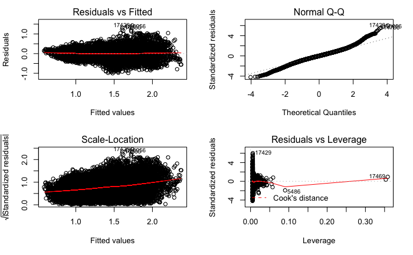

```r
par(mfrow = c(2,2))
plot(test_1_model)
```

Data seems quite well ditributed. There are some outliers, but they don’t seem to influence the data to dramatically.

I will be using following dataframe to compare all Persimonious diagnostic values to help me choose the most suitable explanatory model.

```r
#I can have an all model comparisons in a single tibble.
#I can use add_row to add data.
model_compare <- tibble(model = "test_1_model",
                        Adj_R_sq = round(digits = 4,summary(test_1_model)$adj.r.squared),
                        AIC = round(digits = 4, AIC(test_1_model)),
                        BIC = round(digits = 4, BIC(test_1_model))
                        )
model_compare
```

| model | Adj_R_sq | AIC | BIC |
| --- | --- | --- | --- |
| test_1_model | 0.6478 | -344.6672 | 499.0143 |

*I will limit my model to 4 features*

To try and keep it simple, I will limit my model to max 4 features. I will check if including interactions helps to improve the model performance.

I found that it may be helpful to compare T-values in the overfitted model to get a general feel of which features might be helpful for manual model building.

#### model_1

```r
model_1 <- lm(average_price ~ type +
                year + month + day_of_month + region, data = clean_avocado)
summary(model_1)
```

```
Call:
lm(formula = average_price ~ type + year + month + day_of_month +
    region, data = clean_avocado)

Residuals:
     Min       1Q   Median       3Q      Max
-1.00974 -0.14018  0.00015  0.14097  1.43411

Coefficients:
                           Estimate Std. Error t value Pr(>|t|)
(Intercept)                1.141497   0.017040  66.991  < 2e-16 ***
typeorganic                0.495931   0.003544 139.939  < 2e-16 ***
year2016                  -0.051216   0.004738 -10.810  < 2e-16 ***
year2017                   0.143036   0.004635  30.861  < 2e-16 ***
year2018                   0.064324   0.009152   7.028 2.16e-12 ***
month2                    -0.021525   0.008180  -2.631 0.008509 **
month3                     0.041898   0.008256   5.075 3.91e-07 ***
month4                     0.076561   0.009322   8.213 2.30e-16 ***
month5                     0.050254   0.008435   5.958 2.60e-09 ***
month6                     0.119360   0.009307  12.825  < 2e-16 ***
month7                     0.169614   0.009066  18.709  < 2e-16 ***
month8                     0.190936   0.009354  20.413  < 2e-16 ***
month9                     0.260121   0.009311  27.938  < 2e-16 ***
month10                    0.286190   0.008878  32.236  < 2e-16 ***
month11                    0.176361   0.009048  19.492  < 2e-16 ***
month12                    0.010597   0.009057   1.170 0.242002
day_of_month2              0.043574   0.015559   2.801 0.005106 **
day_of_month3              0.025793   0.013883   1.858 0.063204 .
day_of_month4              0.014805   0.013447   1.101 0.270914
day_of_month5             -0.047685   0.013627  -3.499 0.000468 ***
day_of_month6              0.062916   0.014443   4.356 1.33e-05 ***
day_of_month7              0.034832   0.014509   2.401 0.016370 *
day_of_month8              0.019429   0.013298   1.461 0.144032
day_of_month9              0.006144   0.015559   0.395 0.692935
day_of_month10             0.026241   0.013883   1.890 0.058760 .
day_of_month11             0.009342   0.013447   0.695 0.487232
day_of_month12            -0.019552   0.013627  -1.435 0.151369
day_of_month13             0.056297   0.014436   3.900 9.67e-05 ***
day_of_month14             0.077295   0.014509   5.328 1.01e-07 ***
day_of_month15             0.043704   0.013298   3.286 0.001017 **
```

[output cut: 60 more lines]

```
regionSouthCentral        -0.459793   0.018413 -24.971  < 2e-16 ***
regionSoutheast           -0.163018   0.018413  -8.853  < 2e-16 ***
regionSpokane             -0.115444   0.018413  -6.270 3.70e-10 ***
regionStLouis             -0.130414   0.018413  -7.083 1.47e-12 ***
regionSyracuse            -0.040710   0.018413  -2.211 0.027054 *
regionTampa               -0.152189   0.018413  -8.265  < 2e-16 ***
regionTotalUS             -0.242012   0.018413 -13.143  < 2e-16 ***
regionWest                -0.288817   0.018413 -15.685  < 2e-16 ***
regionWestTexNewMexico    -0.296603   0.018454 -16.072  < 2e-16 ***
---
Signif. codes:  0 ‘***’ 0.001 ‘**’ 0.01 ‘*’ 0.05 ‘.’ 0.1 ‘ ’ 1

Residual standard error: 0.2394 on 18150 degrees of freedom
Multiple R-squared:  0.6485,    Adjusted R-squared:  0.6466
F-statistic: 341.7 on 98 and 18150 DF,  p-value: < 2.2e-16
```

Checking parsimonious numbers, model_1 performs worse than overfitted test_1_model.

```r
model_compare <- model_compare %>%
  add_row(model = "model_1",
          Adj_R_sq = round(digits = 4, summary(model_1)$adj.r.squared),
          AIC = round(digits = 4, AIC(model_1)),
          BIC = round(digits = 4, BIC(model_1))
          )
model_compare
```

| model | Adj_R_sq | AIC | BIC |
| --- | --- | --- | --- |
| test_1_model | 0.6478 | -344.6672 | 499.0143 |
| model_1 | 0.6466 | -293.4439 | 487.7426 |

Check model_1 diagnostic chart

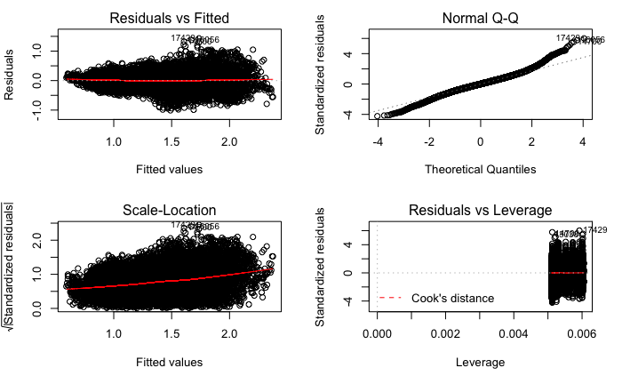

```r
par(mfrow = c(2,2))
plot(model_1)
```

The data is spread quite well, but I am concerned about Residuals vs Leverage - too much data on the extreme right.

#### model_2

model_2 has interactions year:month:day_of_month.

```r
model_2 <- lm(average_price ~ type +
                year:month:day_of_month + region, data = clean_avocado)
```

```r
model_compare <- model_compare %>%
  add_row(model = "model_2",
          Adj_R_sq = round(digits = 4, summary(model_2)$adj.r.squared),
          AIC = round(digits = 4, AIC(model_2)),
          BIC = round(digits = 4, BIC(model_2))
          )
model_compare
```

| model | Adj_R_sq | AIC | BIC |
| --- | --- | --- | --- |
| test_1_model | 0.6478 | -344.6672 | 499.0143 |
| model_2 | 0.6846 | -2246.0990 | -496.2411 |

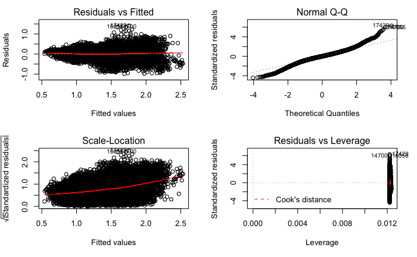

```r
par(mfrow = c(2,2))
plot(model_2)
```

This model has better parsimonious values than is overfitted due to included interactions.

If I am including year:month:day_of_month interaction, am I better off by perorming time series analysis? I feel like I am overfitting by including day_of_month interaction, as this data is at the most granular level and there is possibility that it doesn’t always get recorded.

#### model_3

```r
model_3 <- lm(average_price ~ type +
                year:month + region, data = clean_avocado)
summary(model_3)
```

```
Call:
lm(formula = average_price ~ type + year:month + region, data = clean_avocado)

Residuals:
     Min       1Q   Median       3Q      Max
-1.03699 -0.12405  0.00311  0.13261  1.41658

Coefficients: (10 not defined because of singularities)
                           Estimate Std. Error t value Pr(>|t|)
(Intercept)                1.270916   0.015915  79.858  < 2e-16 ***
typeorganic                0.495932   0.003397 145.984  < 2e-16 ***
regionAtlanta             -0.223077   0.017651 -12.638  < 2e-16 ***
regionBaltimoreWashington -0.026805   0.017651  -1.519 0.128876
regionBoise               -0.212899   0.017651 -12.062  < 2e-16 ***
regionBoston              -0.030148   0.017651  -1.708 0.087648 .
regionBuffaloRochester    -0.044201   0.017651  -2.504 0.012281 *
regionCalifornia          -0.165710   0.017651  -9.388  < 2e-16 ***
regionCharlotte            0.045000   0.017651   2.549 0.010797 *
regionChicago             -0.004260   0.017651  -0.241 0.809271
regionCincinnatiDayton    -0.351834   0.017651 -19.933  < 2e-16 ***
regionColumbus            -0.308254   0.017651 -17.464  < 2e-16 ***
regionDallasFtWorth       -0.475444   0.017651 -26.936  < 2e-16 ***
regionDenver              -0.342456   0.017651 -19.402  < 2e-16 ***
regionDetroit             -0.284941   0.017651 -16.143  < 2e-16 ***
regionGrandRapids         -0.056036   0.017651  -3.175 0.001502 **
regionGreatLakes          -0.222485   0.017651 -12.605  < 2e-16 ***
regionHarrisburgScranton  -0.047751   0.017651  -2.705 0.006830 **
regionHartfordSpringfield  0.257604   0.017651  14.594  < 2e-16 ***
regionHouston             -0.513107   0.017651 -29.070  < 2e-16 ***
regionIndianapolis        -0.247041   0.017651 -13.996  < 2e-16 ***
regionJacksonville        -0.050089   0.017651  -2.838 0.004548 **
regionLasVegas            -0.180118   0.017651 -10.205  < 2e-16 ***
regionLosAngeles          -0.345030   0.017651 -19.548  < 2e-16 ***
regionLouisville          -0.274349   0.017651 -15.543  < 2e-16 ***
regionMiamiFtLauderdale   -0.132544   0.017651  -7.509 6.22e-14 ***
regionMidsouth            -0.156272   0.017651  -8.854  < 2e-16 ***
regionNashville           -0.348935   0.017651 -19.769  < 2e-16 ***
regionNewOrleansMobile    -0.256243   0.017651 -14.517  < 2e-16 ***
regionNewYork              0.166538   0.017651   9.435  < 2e-16 ***
regionNortheast            0.040888   0.017651   2.316 0.020543 *
```

[output cut: 63 more lines]

```
year2018:month10                 NA         NA      NA       NA
year2015:month11          -0.033241   0.013964  -2.380 0.017305 *
year2016:month11           0.186171   0.014812  12.569  < 2e-16 ***
year2017:month11           0.153440   0.014812  10.359  < 2e-16 ***
year2018:month11                 NA         NA      NA       NA
year2015:month12          -0.058361   0.014821  -3.938 8.26e-05 ***
year2016:month12          -0.047856   0.014812  -3.231 0.001236 **
year2017:month12                 NA         NA      NA       NA
year2018:month12                 NA         NA      NA       NA
---
Signif. codes:  0 ‘***’ 0.001 ‘**’ 0.01 ‘*’ 0.05 ‘.’ 0.1 ‘ ’ 1

Residual standard error: 0.2295 on 18156 degrees of freedom
Multiple R-squared:  0.6769,    Adjusted R-squared:  0.6753
F-statistic: 413.5 on 92 and 18156 DF,  p-value: < 2.2e-16
```

```r
model_compare <- model_compare %>%
  add_row(model = "model_3",
          Adj_R_sq = round(digits = 4, summary(model_3)$adj.r.squared),
          AIC = round(digits = 4, AIC(model_3)),
          BIC = round(digits = 4, BIC(model_3))
          )
model_compare
```

| model | Adj_R_sq | AIC | BIC |
| --- | --- | --- | --- |
| test_1_model | 0.6478 | -344.6672 | 499.0143 |
| model_2 | 0.6846 | -2246.0990 | -496.2411 |
| model_3 | 0.6753 | -1842.9290 | -1108.6136 |

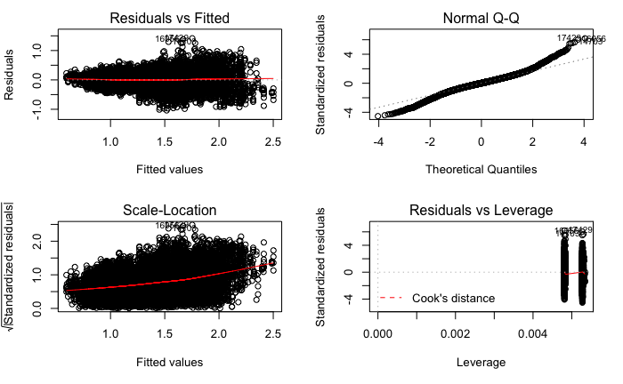

```r
par(mfrow = c(2,2))
plot(model_3)
```

So far model_3 seems to be the most suitable and year:month are more likely to be recorded than year:month:day_of_month. Also year:month is less granular, therefore I don’t feel guilty for potentially overfitting the data.

#### model_4

```r
model_4 <- lm(average_price ~ type:region +
              year:month, data = clean_avocado)
summary(model_4)
```

```
Call:
lm(formula = average_price ~ type:region + year:month, data = clean_avocado)

Residuals:
     Min       1Q   Median       3Q      Max
-1.07719 -0.11083  0.00457  0.11973  1.45733

Coefficients: (11 not defined because of singularities)
                                            Estimate Std. Error t value Pr(>|t|)
(Intercept)                                 1.647764   0.019026  86.605  < 2e-16 ***
typeconventional:regionAlbany              -0.341190   0.023512 -14.511  < 2e-16 ***
typeorganic:regionAlbany                    0.083366   0.023512   3.546 0.000393 ***
typeconventional:regionAtlanta             -0.621131   0.023512 -26.418  < 2e-16 ***
typeorganic:regionAtlanta                  -0.082847   0.023512  -3.524 0.000427 ***
typeconventional:regionBaltimoreWashington -0.345746   0.023512 -14.705  < 2e-16 ***
typeorganic:regionBaltimoreWashington       0.034313   0.023512   1.459 0.144476
typeconventional:regionBoise               -0.613912   0.023512 -26.111  < 2e-16 ***
typeorganic:regionBoise                    -0.069710   0.023512  -2.965 0.003032 **
typeconventional:regionBoston              -0.385568   0.023512 -16.399  < 2e-16 ***
typeorganic:regionBoston                    0.067449   0.023512   2.869 0.004126 **
typeconventional:regionBuffaloRochester    -0.307639   0.023512 -13.084  < 2e-16 ***
typeorganic:regionBuffaloRochester         -0.038586   0.023512  -1.641 0.100789
typeconventional:regionCalifornia          -0.584503   0.023512 -24.860  < 2e-16 ***
typeorganic:regionCalifornia               -0.004740   0.023512  -0.202 0.840231
typeconventional:regionCharlotte           -0.414858   0.023512 -17.644  < 2e-16 ***
typeorganic:regionCharlotte                 0.247035   0.023512  10.507  < 2e-16 ***
typeconventional:regionChicago             -0.320598   0.023512 -13.635  < 2e-16 ***
typeorganic:regionChicago                   0.054254   0.023512   2.307 0.021038 *
typeconventional:regionCincinnatiDayton    -0.674444   0.023512 -28.685  < 2e-16 ***
typeorganic:regionCincinnatiDayton         -0.287048   0.023512 -12.209  < 2e-16 ***
typeconventional:regionColumbus            -0.623675   0.023512 -26.526  < 2e-16 ***
typeorganic:regionColumbus                 -0.250657   0.023512 -10.661  < 2e-16 ***
typeconventional:regionDallasFtWorth       -0.843497   0.023512 -35.875  < 2e-16 ***
typeorganic:regionDallasFtWorth            -0.365213   0.023512 -15.533  < 2e-16 ***
typeconventional:regionDenver              -0.615983   0.023512 -26.199  < 2e-16 ***
typeorganic:regionDenver                   -0.326752   0.023512 -13.897  < 2e-16 ***
typeconventional:regionDetroit             -0.565983   0.023512 -24.072  < 2e-16 ***
typeorganic:regionDetroit                  -0.261722   0.023512 -11.131  < 2e-16 ***
typeconventional:regionGrandRapids         -0.364918   0.023512 -15.520  < 2e-16 ***
typeorganic:regionGrandRapids              -0.004977   0.023512  -0.212 0.832368
```

[output cut: 117 more lines]

```
year2018:month10                                  NA         NA      NA       NA
year2015:month11                           -0.033241   0.013094  -2.539 0.011138 *
year2016:month11                            0.186171   0.013888  13.405  < 2e-16 ***
year2017:month11                            0.153440   0.013888  11.048  < 2e-16 ***
year2018:month11                                  NA         NA      NA       NA
year2015:month12                           -0.057950   0.013897  -4.170 3.06e-05 ***
year2016:month12                           -0.047856   0.013888  -3.446 0.000571 ***
year2017:month12                                  NA         NA      NA       NA
year2018:month12                                  NA         NA      NA       NA
---
Signif. codes:  0 ‘***’ 0.001 ‘**’ 0.01 ‘*’ 0.05 ‘.’ 0.1 ‘ ’ 1

Residual standard error: 0.2152 on 18103 degrees of freedom
Multiple R-squared:  0.7168,    Adjusted R-squared:  0.7145
F-statistic:   316 on 145 and 18103 DF,  p-value: < 2.2e-16
```

```r
model_compare <- model_compare %>%
  add_row(model = "model_4",
          Adj_R_sq = round(digits = 4, summary(model_4)$adj.r.squared),
          AIC = round(digits = 4, AIC(model_4)),
          BIC = round(digits = 4, BIC(model_4))
          )
model_compare
```

| model | Adj_R_sq | AIC | BIC |
| --- | --- | --- | --- |
| test_1_model | 0.6478 | -344.6672 | 499.0143 |
| model_2 | 0.6846 | -2246.0990 | -496.2411 |
| model_3 | 0.6753 | -1842.9290 | -1108.6136 |
| model_4 | 0.7145 | -4139.0015 | -2990.6573 |

model_4 is the strongest so far, unless I am going overboard :) I wish I took note of R-Sq values in addition to Adj_R_sq.

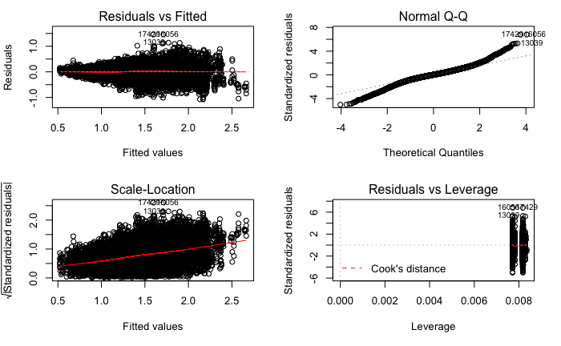

```r
par(mfrow = c(2,2))
plot(model_4)
```

#### model_5

```r
model_5 <- lm(average_price ~ type:region +
              month, data = clean_avocado)
summary(model_5)
```

```
Call:
lm(formula = average_price ~ type:region + month, data = clean_avocado)

Residuals:
     Min       1Q   Median       3Q      Max
-1.06386 -0.14344 -0.00634  0.13492  1.58555

Coefficients: (1 not defined because of singularities)
                                            Estimate Std. Error t value Pr(>|t|)
(Intercept)                                 1.593443   0.019318  82.485  < 2e-16 ***
month2                                     -0.036632   0.007933  -4.618 3.91e-06 ***
month3                                      0.021236   0.007809   2.720 0.006542 **
month4                                      0.063362   0.008404   7.540 4.93e-14 ***
month5                                      0.035582   0.008228   4.325 1.54e-05 ***
month6                                      0.098382   0.008609  11.428  < 2e-16 ***
month7                                      0.151058   0.008228  18.360  < 2e-16 ***
month8                                      0.201496   0.008404  23.977  < 2e-16 ***
month9                                      0.261636   0.008605  30.406  < 2e-16 ***
month10                                     0.268664   0.008228  32.654  < 2e-16 ***
month11                                     0.144544   0.008404  17.200  < 2e-16 ***
month12                                     0.020295   0.008406   2.414 0.015769 *
typeconventional:regionAlbany              -0.339689   0.026220 -12.955  < 2e-16 ***
typeorganic:regionAlbany                    0.084868   0.026220   3.237 0.001211 **
typeconventional:regionAtlanta             -0.619630   0.026220 -23.631  < 2e-16 ***
typeorganic:regionAtlanta                  -0.081346   0.026220  -3.102 0.001923 **
typeconventional:regionBaltimoreWashington -0.344245   0.026220 -13.129  < 2e-16 ***
typeorganic:regionBaltimoreWashington       0.035814   0.026220   1.366 0.171991
typeconventional:regionBoise               -0.612411   0.026220 -23.356  < 2e-16 ***
typeorganic:regionBoise                    -0.068209   0.026220  -2.601 0.009293 **
typeconventional:regionBoston              -0.384067   0.026220 -14.648  < 2e-16 ***
typeorganic:regionBoston                    0.068950   0.026220   2.630 0.008555 **
typeconventional:regionBuffaloRochester    -0.306138   0.026220 -11.676  < 2e-16 ***
typeorganic:regionBuffaloRochester         -0.037085   0.026220  -1.414 0.157274
typeconventional:regionCalifornia          -0.583002   0.026220 -22.235  < 2e-16 ***
typeorganic:regionCalifornia               -0.003239   0.026220  -0.124 0.901690
typeconventional:regionCharlotte           -0.413357   0.026220 -15.765  < 2e-16 ***
typeorganic:regionCharlotte                 0.248536   0.026220   9.479  < 2e-16 ***
typeconventional:regionChicago             -0.319097   0.026220 -12.170  < 2e-16 ***
typeorganic:regionChicago                   0.055755   0.026220   2.126 0.033484 *
typeconventional:regionCincinnatiDayton    -0.672943   0.026220 -25.665  < 2e-16 ***
```

[output cut: 80 more lines]

```
typeorganic:regionSyracuse                 -0.034718   0.026220  -1.324 0.185490
typeconventional:regionTampa               -0.486848   0.026220 -18.567  < 2e-16 ***
typeorganic:regionTampa                    -0.072351   0.026220  -2.759 0.005798 **
typeconventional:regionTotalUS             -0.596434   0.026220 -22.747  < 2e-16 ***
typeorganic:regionTotalUS                  -0.142411   0.026220  -5.431 5.67e-08 ***
typeconventional:regionWest                -0.703357   0.026220 -26.825  < 2e-16 ***
typeorganic:regionWest                     -0.129097   0.026220  -4.924 8.58e-07 ***
typeconventional:regionWestTexNewMexico    -0.846316   0.026220 -32.277  < 2e-16 ***
typeorganic:regionWestTexNewMexico                NA         NA      NA       NA
---
Signif. codes:  0 ‘***’ 0.001 ‘**’ 0.01 ‘*’ 0.05 ‘.’ 0.1 ‘ ’ 1

Residual standard error: 0.2399 on 18130 degrees of freedom
Multiple R-squared:  0.6472,    Adjusted R-squared:  0.6449
F-statistic: 281.9 on 118 and 18130 DF,  p-value: < 2.2e-16
```

```r
model_compare <- model_compare %>%
  add_row(model = "model_5",
          Adj_R_sq = round(digits = 4, summary(model_5)$adj.r.squared),
          AIC = round(digits = 4, AIC(model_5)),
          BIC = round(digits = 4, BIC(model_5))
          )
model_compare
```

| model | Adj_R_sq | AIC | BIC |
| --- | --- | --- | --- |
| test_1_model | 0.6478 | -344.6672 | 499.0143 |
| model_2 | 0.6846 | -2246.0990 | -496.2411 |
| model_3 | 0.6753 | -1842.9290 | -1108.6136 |
| model_4 | 0.7145 | -4139.0015 | -2990.6573 |
| model_5 | 0.6449 | -186.0565 | 751.3674 |

Removing annual variation from the model changes its parsimonious diagnostic values.

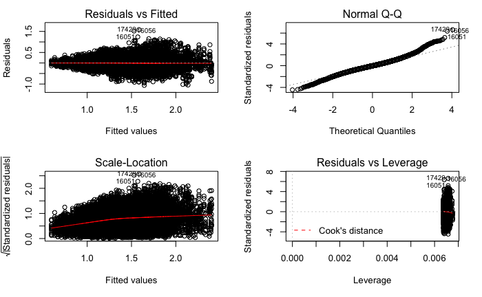

```r
par(mfrow = c(2,2))
plot(model_5)
```

However data distribution seems to be the best of all models, except for Residuals vs Leverage.

#### model_6

```r
model_6 <- lm(average_price ~ type +
              year:month, data = clean_avocado)
summary(model_6)
```

```
Call:
lm(formula = average_price ~ type + year:month, data = clean_avocado)

Residuals:
    Min      1Q  Median      3Q     Max
-1.2069 -0.1699 -0.0122  0.1689  1.4449

Coefficients: (10 not defined because of singularities)
                  Estimate Std. Error t value Pr(>|t|)
(Intercept)       1.115862   0.012335  90.461  < 2e-16 ***
typeorganic       0.495979   0.004182 118.588  < 2e-16 ***
year2015:month1   0.001194   0.018235   0.066 0.947774
year2016:month1  -0.123667   0.017192  -7.193 6.57e-13 ***
year2017:month1  -0.086352   0.017192  -5.023 5.14e-07 ***
year2018:month1   0.023579   0.018235   1.293 0.196012
year2015:month2  -0.036907   0.018235  -2.024 0.042986 *
year2016:month2  -0.126745   0.018235  -6.951 3.76e-12 ***
year2017:month2  -0.149060   0.018235  -8.174 3.17e-16 ***
year2018:month2  -0.045148   0.018235  -2.476 0.013299 *
year2015:month3  -0.001870   0.017192  -0.109 0.913369
year2016:month3  -0.139639   0.018235  -7.658 1.99e-14 ***
year2017:month3   0.035083   0.018235   1.924 0.054376 .
year2018:month3  -0.027394   0.018235  -1.502 0.133051
year2015:month4   0.019597   0.018235   1.075 0.282522
year2016:month4  -0.158829   0.018235  -8.710  < 2e-16 ***
year2017:month4   0.138759   0.017192   8.071 7.40e-16 ***
year2018:month4         NA         NA      NA       NA
year2015:month5  -0.019167   0.017192  -1.115 0.264929
year2016:month5  -0.164130   0.017192  -9.547  < 2e-16 ***
year2017:month5   0.168741   0.018235   9.254  < 2e-16 ***
year2018:month5         NA         NA      NA       NA
year2015:month6   0.035222   0.018235   1.932 0.053428 .
year2016:month6  -0.080796   0.018235  -4.431 9.44e-06 ***
year2017:month6   0.182697   0.018259  10.006  < 2e-16 ***
year2018:month6         NA         NA      NA       NA
year2015:month7   0.045593   0.018235   2.500 0.012418 *
year2016:month7   0.037481   0.017192   2.180 0.029259 *
year2017:month7   0.201074   0.017192  11.696  < 2e-16 ***
year2018:month7         NA         NA      NA       NA
year2015:month8   0.080630   0.017192   4.690 2.75e-06 ***
```

[output cut: 10 more lines]

```
year2018:month10        NA         NA      NA       NA
year2015:month11 -0.033241   0.017192  -1.933 0.053192 .
year2016:month11  0.186171   0.018235  10.210  < 2e-16 ***
year2017:month11  0.153440   0.018235   8.415  < 2e-16 ***
year2018:month11        NA         NA      NA       NA
year2015:month12 -0.058033   0.018247  -3.180 0.001473 **
year2016:month12 -0.047856   0.018235  -2.624 0.008687 **
year2017:month12        NA         NA      NA       NA
year2018:month12        NA         NA      NA       NA
---
Signif. codes:  0 ‘***’ 0.001 ‘**’ 0.01 ‘*’ 0.05 ‘.’ 0.1 ‘ ’ 1

Residual standard error: 0.2825 on 18209 degrees of freedom
Multiple R-squared:  0.5089,    Adjusted R-squared:  0.5078
F-statistic: 483.8 on 39 and 18209 DF,  p-value: < 2.2e-16
```

```r
model_compare <- model_compare %>%
  add_row(model = "model_6",
          Adj_R_sq = round(digits = 4, summary(model_6)$adj.r.squared),
          AIC = round(digits = 4, AIC(model_6)),
          BIC = round(digits = 4, BIC(model_6))
          )
model_compare
```

| model | Adj_R_sq | AIC | BIC |
| --- | --- | --- | --- |
| test_1_model | 0.6478 | -344.6672 | 499.0143 |
| model_2 | 0.6846 | -2246.0990 | -496.2411 |
| model_3 | 0.6753 | -1842.9290 | -1108.6136 |
| model_4 | 0.7145 | -4139.0015 | -2990.6573 |
| model_5 | 0.6449 | -186.0565 | 751.3674 |
| model_6 | 0.5078 | 5693.5618 | 6013.8483 |

Excluding Region reduces model accuracy, therefore I will not pursue it.

### Further fine tuning and diagnostics.

I feel that model_4 & model_5 are good contenders to undergo further diagnostics.

model_4 has very good parsimonious values, but model_5 has the best distribution of data. #### Train & Test

create training and testing sets

*model_4

```r
n_data <- nrow(clean_avocado) #18249 rows
test_index <- sample(1:n_data, size = n_data * 0.2)

train_set <- slice(clean_avocado, -test_index)
test_set <- slice(clean_avocado, test_index)
```

```r
model_4_train <- lm(average_price ~ type:region +
                    year:month , data = train_set)
model_4_predict <- predict(model_4_train, newdata = test_set)
```

```
prediction from a rank-deficient fit may be misleading
```

```r
model_5_train <- lm(average_price ~ type:region +
                    month, data = train_set)
model_5_predict <- predict(model_5_train, newdata = test_set)
```

```
prediction from a rank-deficient fit may be misleading
```

model_4 & model_5 train_vs_predict performance.

```r
median(abs(model_4_predict - test_set$average_price))
```

```
[1] 0.1158815
```

```r
median(abs(model_5_predict - test_set$average_price))
```

```
[1] 0.1361641
```

Prediction error in model_4 is lower than in model_5.

In model_4 some intercations cannot be calculated and I am getting NAs.

This is why I am getting a warning: “prediction from a rank-deficient fit may be misleading”.

Also p-value is over 5% for some type:region interactions, I wonder if transforming data will help overcome this issue?

I will first attemt K-fold validation:

```r
library(caret)
```

```r
cv_model_4 <- trainControl(method = "cv",
                            number = 10,
                            savePredictions = TRUE)
model_4_fold <- train(average_price ~ type:region +
                    year:month, data = clean_avocado,
                    trControl = cv_model_4, method = "lm")
```

[output not shown]

```r
###########
cv_model_5 <- trainControl(method = "cv",
                           number = 10,
                           savePredictions = TRUE)
model_5_fold <- train(average_price ~ type:region +
              month, data = clean_avocado, trControl = cv_model_5, method = "lm")
```

[output not shown]

```r
mean(model_4_fold$resample$RMSE)
```

```
[1] 0.2160507
```

```r
mean(model_4_fold$resample$Rsquared)
```

```
[1] 0.7122739
```

```r
#####
mean(model_5_fold$resample$RMSE)
```

```
[1] 0.2408383
```

```r
mean(model_5_fold$resample$Rsquared)
```

```
[1] 0.6424065
```

*Same as in parsimonious tests model_4 performs better than model_5*

I found it useful to run train&test diagnostic and/or K-fold test, because both of them pointed out that my models may be misleading due to model’s inability to calculculate effect of some interactions.

##Predictive model.

Just going to try using “gmulti” to see again how it works.

```r
library(glmulti)
```

```r
future_avocado_model <- glmulti(average_price ~
                                total_volume + x4046 +
                                x4225 + x4770 + total_bags +
                                small_bags + large_bags +
                                x_large_bags + type +
                                year + region + month +
                                day_of_month, data = clean_avocado,
                                method = "g", level = 1, , plotty = FALSE)
```

[output not shown]

[output cut: 581 more lines]

[output not shown]

```r
summary(future_avocado_model)
```

```
$name
[1] "glmulti.analysis"

$method
[1] "g"

$fitting
[1] "glm"

$crit
[1] "aic"

$level
[1] 1

$marginality
[1] FALSE

$confsetsize
[1] 100

$bestic
[1] -350.1661

$icvalues
  [1] -350.16607 -348.35796 -348.35795 -348.35795 -348.35788 -348.26657 -348.20211
  [8] -347.27338 -347.20329 -346.36011 -346.36011 -346.35882 -346.35882 -346.35881
 [15] -346.35854 -346.35189 -345.93100 -345.74054 -345.74047 -345.46299 -345.33957
 [22] -345.31783 -345.27736 -345.27659 -345.26783 -344.25250 -344.19410 -344.19409
 [29] -344.19409 -343.52637 -343.37358 -343.31935 -343.31934 -343.31927 -343.27547
 [36] -343.24067 -343.06938 -342.31757 -341.81795 -341.64661 -340.55481 -340.27844
 [43] -340.27844 -340.18351 -339.57679 -339.50603 -339.50595 -339.18098 -338.69825
 [50] -338.53889 -338.37944 -338.37915 -338.14249 -338.04607 -337.97752 -337.61554
 [57] -337.58519 -337.57333 -337.57333 -336.46335 -336.44609 -335.63869 -335.63380
 [64] -325.41305 -321.22205 -320.64465 -319.76451 -318.07312 -316.81466 -315.00248
 [71] -314.84053 -314.70436 -311.84431 -310.24572 -308.67437 -308.32310 -307.96796
 [78] -306.53445 -306.11632 -304.45644 -301.96989 -300.72781 -300.28508 -299.65085
 [85] -298.93578 -298.29389 -297.90019 -297.37328 -295.82853 -295.00545 -294.32917
 [92] -294.02986 -292.82968 -292.12885  -80.59624  -78.70782  -78.70781  -78.60585
 [99]  -77.41237  -76.76639
```

[output cut: 17 more lines]

```
 [67] 3.941686e-08 1.692002e-08 9.018403e-09 3.644352e-09 3.360870e-09 3.139668e-09
 [73] 7.513319e-10 3.378324e-10 1.539887e-10 1.291843e-10 1.081666e-10 5.282151e-11
 [79] 4.285623e-11 1.868857e-11 5.390499e-12 2.896774e-12 2.321545e-12 1.690659e-12
 [85] 1.182444e-12 8.578192e-13 7.045376e-13 5.413608e-13 2.500632e-13 1.656988e-13
 [91] 1.181593e-13 1.017358e-13 5.582856e-14 3.932554e-14 4.580908e-60 1.781910e-60
 [97] 1.781907e-60 1.693340e-60 9.323576e-61 6.750114e-61

$generations
[1] 1050

$elapsed
[1] 0.2312308

$includeobjects
[1] TRUE
```

```r
summary(future_avocado_model)$bestmodel
```

```
[1] "average_price ~ 1 + year + month + day_of_month + x4225 + x4770 + "
[2] "    large_bags + x_large_bags + type + region"
```

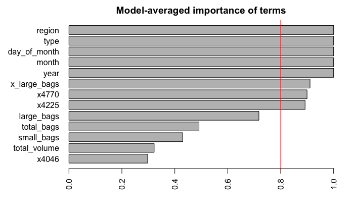

```r
# relative importance of features
plot(future_avocado_model, type = "s")
```

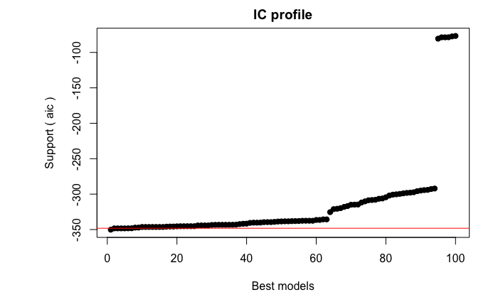

```r
#models below the red line are worth considering, however the algorithm is likely to have chosen the best suitable model
plot(future_avocado_model, type = "p")
```

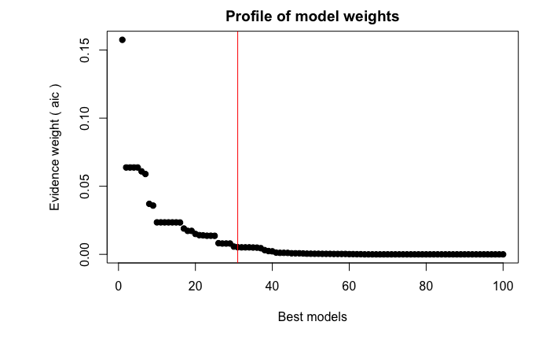

```r
plot(future_avocado_model, type = "w")
```

Display the list of all models in ranked order from best to worst.

| model | aic | weights |
| --- | --- | --- |
| average_price ~ 1 + year + month + day_of_month + x4225 + x4770 + large_bags + x_large_bags + type + region | -350.16607 | 1.575058e-01 |
| average_price ~ 1 + year + month + day_of_month + x4225 + x4770 + total_bags + small_bags + x_large_bags + type + region | -348.35796 | 6.377774e-02 |
| average_price ~ 1 + year + month + day_of_month + x4225 + x4770 + small_bags + large_bags + x_large_bags + type + region | -348.35795 | 6.377765e-02 |
| average_price ~ 1 + year + month + day_of_month + x4225 + x4770 + total_bags + large_bags + x_large_bags + type + region | -348.35795 | 6.377764e-02 |
| average_price ~ 1 + year + month + day_of_month + x4225 + x4770 + total_bags + small_bags + large_bags + type + region | -348.35788 | 6.377549e-02 |
| average_price ~ 1 + year + month + day_of_month + total_volume + x4225 + x4770 + large_bags + x_large_bags + type + region | -348.26657 | 6.092901e-02 |
| average_price ~ 1 + year + month + day_of_month + x4046 + x4225 + x4770 + large_bags + x_large_bags + type + region | -348.20211 | 5.899671e-02 |
| average_price ~ 1 + year + month + day_of_month + x4225 + x4770 + total_bags + small_bags + large_bags + x_large_bags + type + region | -347.27338 | 3.708140e-02 |
| average_price ~ 1 + year + month + day_of_month + x4225 + x4770 + total_bags + x_large_bags + type + region | -347.20329 | 3.580435e-02 |
| average_price ~ 1 + year + month + day_of_month + total_volume + x4046 + x4770 + total_bags + small_bags + x_large_bags + type + region | -346.36011 | 2.348777e-02 |

[output cut: 90 more lines]

So the best model suggested by GLMulti is: average_price ~ year + month + day_of_month + x4225 + x4770 + large_bags + x_large_bags + type + region.

I will now test it:

```r
glmulti_avo_model_1 <- lm(average_price ~ year + month +
                          day_of_month + x4225 + x4770 +
                          large_bags + x_large_bags + type +
                          region,
                        data = clean_avocado)
summary(glmulti_avo_model_1)
```

```
Call:
lm(formula = average_price ~ year + month + day_of_month + x4225 +
    x4770 + large_bags + x_large_bags + type + region, data = clean_avocado)

Residuals:
     Min       1Q   Median       3Q      Max
-1.00073 -0.13916 -0.00033  0.14116  1.43483

Coefficients:
                            Estimate Std. Error t value Pr(>|t|)
(Intercept)                1.148e+00  1.706e-02  67.294  < 2e-16 ***
year2016                  -5.287e-02  4.769e-03 -11.086  < 2e-16 ***
year2017                   1.417e-01  4.701e-03  30.139  < 2e-16 ***
year2018                   6.209e-02  9.204e-03   6.745 1.57e-11 ***
month2                    -2.272e-02  8.169e-03  -2.781 0.005425 **
month3                     3.998e-02  8.246e-03   4.848 1.25e-06 ***
month4                     7.497e-02  9.309e-03   8.053 8.55e-16 ***
month5                     4.871e-02  8.425e-03   5.781 7.53e-09 ***
month6                     1.143e-01  9.315e-03  12.266  < 2e-16 ***
month7                     1.640e-01  9.088e-03  18.046  < 2e-16 ***
month8                     1.880e-01  9.352e-03  20.105  < 2e-16 ***
month9                     2.596e-01  9.299e-03  27.918  < 2e-16 ***
month10                    2.852e-01  8.865e-03  32.170  < 2e-16 ***
month11                    1.757e-01  9.038e-03  19.435  < 2e-16 ***
month12                    1.013e-02  9.046e-03   1.120 0.262683
day_of_month2              4.275e-02  1.554e-02   2.752 0.005934 **
day_of_month3              2.284e-02  1.387e-02   1.648 0.099463 .
day_of_month4              1.481e-02  1.343e-02   1.103 0.269958
day_of_month5             -4.758e-02  1.361e-02  -3.497 0.000472 ***
day_of_month6              6.065e-02  1.442e-02   4.205 2.62e-05 ***
day_of_month7              3.391e-02  1.449e-02   2.341 0.019247 *
day_of_month8              1.875e-02  1.328e-02   1.413 0.157816
day_of_month9              5.334e-03  1.553e-02   0.343 0.731316
day_of_month10             2.450e-02  1.386e-02   1.767 0.077172 .
day_of_month11             8.039e-03  1.343e-02   0.599 0.549370
day_of_month12            -2.025e-02  1.361e-02  -1.488 0.136715
day_of_month13             5.488e-02  1.442e-02   3.807 0.000141 ***
day_of_month14             7.719e-02  1.449e-02   5.328 1.00e-07 ***
day_of_month15             4.265e-02  1.328e-02   3.212 0.001321 **
day_of_month16             2.977e-02  1.553e-02   1.916 0.055377 .
```

[output cut: 64 more lines]

```
regionSouthCentral        -4.580e-01  1.845e-02 -24.819  < 2e-16 ***
regionSoutheast           -1.590e-01  1.856e-02  -8.566  < 2e-16 ***
regionSpokane             -1.158e-01  1.838e-02  -6.298 3.08e-10 ***
regionStLouis             -1.312e-01  1.838e-02  -7.136 9.94e-13 ***
regionSyracuse            -4.103e-02  1.838e-02  -2.232 0.025620 *
regionTampa               -1.519e-01  1.839e-02  -8.263  < 2e-16 ***
regionTotalUS             -2.025e-01  2.255e-02  -8.983  < 2e-16 ***
regionWest                -2.654e-01  1.913e-02 -13.874  < 2e-16 ***
regionWestTexNewMexico    -2.962e-01  1.844e-02 -16.064  < 2e-16 ***
---
Signif. codes:  0 ‘***’ 0.001 ‘**’ 0.01 ‘*’ 0.05 ‘.’ 0.1 ‘ ’ 1

Residual standard error: 0.239 on 18146 degrees of freedom
Multiple R-squared:  0.6498,    Adjusted R-squared:  0.6478
F-statistic: 330.1 on 102 and 18146 DF,  p-value: < 2.2e-16
```

glmulti_avo_model_1 (suggested by glmulti). It has R-sq of 0.6498 and adj-R-sq of 0.6478, which suggests to me that it may be overfitted. RSE is 0.239.

| model | Adj_R_sq | AIC | BIC |
| --- | --- | --- | --- |
| test_1_model | 0.6478 | -344.6672 | 499.0143 |
| model_2 | 0.6846 | -2246.0990 | -496.2411 |
| model_3 | 0.6753 | -1842.9290 | -1108.6136 |
| model_4 | 0.7145 | -4139.0015 | -2990.6573 |
| model_5 | 0.6449 | -186.0565 | 751.3674 |
| model_6 | 0.5078 | 5693.5618 | 6013.8483 |
| glmulti_avo_model_1 | 0.6478 | -350.1661 | 462.2679 |

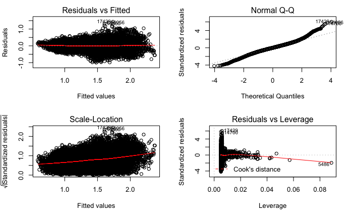

```r
par(mfrow = c(2,2))
plot(glmulti_avo_model_1)
```

This model also seems to have the best distribution of data.

Now test it versus model_4 using K-fold:

```r
glmulti_avo_model_1_k <- trainControl(method = "cv",
                                    number = 10,
                                    savePredictions = TRUE)
glmulti_avo_model_1_fold <- train(average_price ~ year + month +
                          day_of_month + x4225 + x4770 +
                          large_bags + x_large_bags + type +
                          region,
                          data = clean_avocado,
                          trControl = glmulti_avo_model_1_k, method = "lm")
```

No warnings / errors with this model, it is very promising :)

```r
mean(model_4_fold$resample$RMSE)
```

```
[1] 0.2160703
```

```r
mean(model_4_fold$resample$Rsquared)
```

```
[1] 0.7120004
```

```r
#####
mean(glmulti_avo_model_1_fold$resample$RMSE)
```

```
[1] 0.2396877
```

```r
mean(glmulti_avo_model_1_fold$resample$Rsquared)
```

```
[1] 0.6458032
```

GLMulti model does not seem to be as good as model_4

# QUIZ

## 1. I want to predict how well 6 year-olds are going to do in their final school exams. Using the following variables am I likely under-fitting, fitting well or over-fitting? Postcode, gender, reading level, score in maths test, date of birth, family income.

If the math test is mandatory for all pupils, this model may be helpful in predicting the final exam results.

Including date of birth, I believe will tend toward overfitting. We should make sure that the training dataset contains information of 6-year olds only.

## 3. I have two models, the first with: r-squared: 0.44, adjusted r-squared: 0.43. The second with: r-squared: 0.47, adjusted r-squared: 0.41. Which one should I use?

Generally speaking the higher r-squared/adjusted r-squared values are better. But while r-squared will be increasing with each additional feature, adjusted r-square will converge and start decreasing at some point. The point of convergence indicates that the model is overfitted.

## 5. How does k-fold validation work?

A dataset is split into K-number of folds. Each fold is used for testing at some point during iterations, the other folds are used to train the model. Iterations continue until each fold has been used as test set.

## 6. What is a validation set? When do you need one?

A validation set can be used between training and testing. Once a few candidate models have been selected, they could be fine tuned using a validation set, to make sure they do not overfit. The next step is to test the models on a test set to make sure they perform as expected (hoped for).

## 7. Describe how backwards selection works.

It establishes the most optimal model features by starting from the most overfitted model and working backwards, eliminating features, until the modelbecomes well-fitted.

## 8. Describe how best subset selection works.

Best subset regression compares all possible models using specified predictors and displays the best fitting models that have x-number of predictors. the output provides a list of models with their summary statistics.

The alternative is Stepwise Regression, which might be easier to interpret.

## 9. It is estimated on 5% of model projects end up being deployed. What actions can you take to maximise the likelihood of your model being deployed?

Be able to explain what the model does and why it is useful and if it does what it needs to do. Document the model!

Train, Validate, Test. Be able to explain and justify inclusion/exclusion of parameters.

## 10. What metric could you use to confirm that the recent population is similar to the development population?

mean(pop) - mean(dev_pop)

## 11. How is the Population Stability Index defined? What does this mean in words?

PSI could help in determing if the data has changed significantly and if an existing model is still suitable to use on new data.

Events such as changes in product characteristics or large socioeconomic events could deem models useless. Model performance is prone to deteriorating over time in general.

## 12. Above what PSI value might we need to start to consider rebuilding or recalibrating the model.

If PSI score goes over 0.2 the model needs to be replaced / recalibrated.

## 13. What are the common errors that can crop up when implementing a model?

https://www.strategywise.com/five-common-errors-to-avoid-when-building-predictive-models/

- Lack of understanding of the business use case.
- Lack of Data Integrity.
- The model over or under fits.
- Bias/Variance imbalance.

It is important to build balanced (not too complex and not too simple). Overly complex models will tend to have too much variance in their outputs. Overly simple models are likely to produce biased outputs.

- Testing and evaluation errors.

## 14. After performance monitoring, if we find that the discrimination is still satisfactory but the accuracy has deteriorated, what is the recommended action?

Root cause should be investigated and the model should be recalibrated/rebuilt.

## 15. Why is it important to have a unique model identifier for each model?

So that models can be identified/distinguished from others.

## 16. Why is it important to document the modelling rationale and approach?

So that the model can be understood by others, e.g. for audit purposes.